# Part II - (The determinant of interest rate and loan amount from Prosper Loan Data Analysis)

## by (Mutholib Yusira)

## Investigation Overview

> Prosper is a money lending platform which helps in reducing the distance between the borrower and lender(peer-to-peer lending process). The objective of this work is to look at the main determinants of loans and borrowers interest rate that could be used to predict their evolution. The main focus was on several borrowers information, such as income, occupation, interest rate ....

## Dataset Overview

> The Prosper loan dataset comprises of 113937 loan entries with 81 attributes on each loan, including loan amount, borrower rate (or interest rate), current loan status, borrower income, and many others, from the year 2009-2014. There are two main categories:
> - Borrower information: Basic attributes of the borrowers such as annual income, condition of employment, interest rate, loan status, etc.
> - Loan performance information: Metrics evaluating the risk associated with the loans such as Prosper score and bank card utilization, etc.

> There were some elements that need to be fixed, in order to create interesting and trustworthy analyses and visualizations.

## Loan Original Amount Distribution

There are 3 peaks of the Loan Original Amount, at 4k, 10k and 15k. These 3 loan amounts are the most common loan amounts borrowed with 4k being the highest

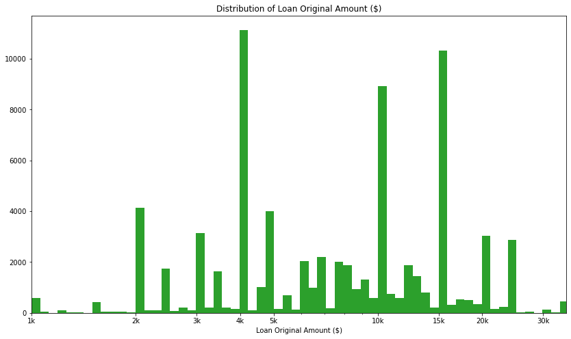

## Loan Status Distribution

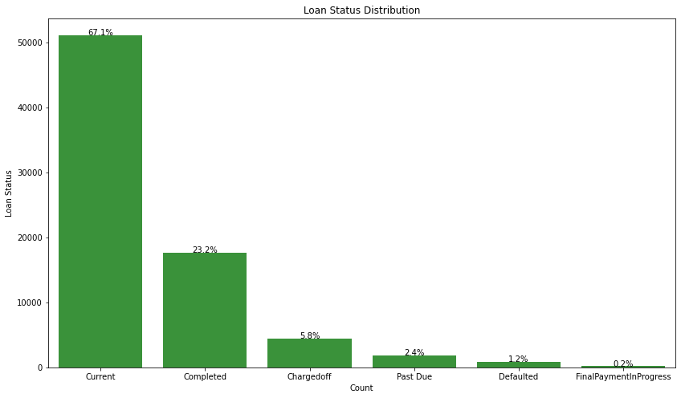

## Relationship Between Borrower Rate and Employment Status

Borrowers with full time jobs and with a stable source of income (Employed, Full-time, SElf-employed), had lower interest loans that others. There is only one unemployed borrower in the dataset, and that person has a very high interest rate compared to most of the borrowers.

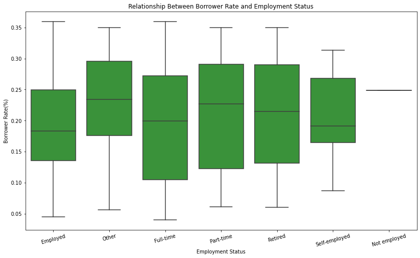

## Relationship Between Borrower Rate and Home Owner Status

Borrowers who are homeowners and possibly use those homes as collateral have a lower interest rate than borrowers who do not have homes.

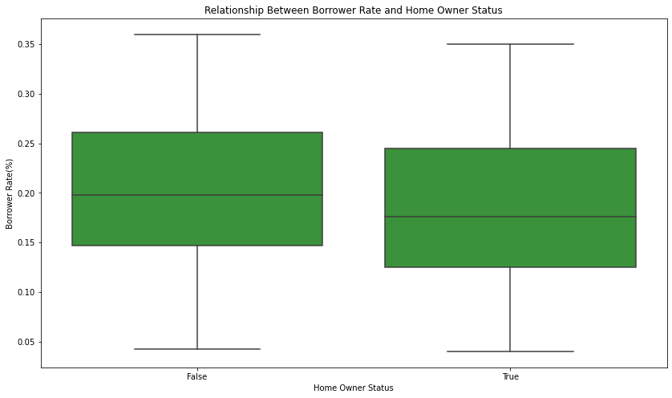

## Relationship Between Borrower Rate and Income Group

There is a negative correlation between the income groups of the borrowers and the interest rate on the loans they take out. The high income group have the lowest loan interest rate, and the low income group have the highest interest rate.

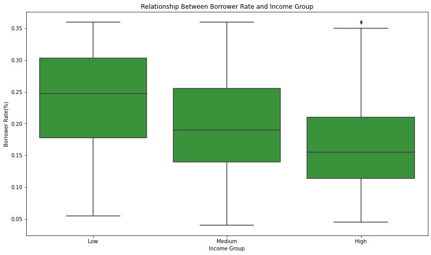

## Relationship Between Borrower Rate and Prosper Score, Rating

Either the Prosper Score or Prosper Rating is a really good determinant of the loan interest rate. The higher the Prosper Score, the lower the interest rate on the loans. Higher Prosper Ratings are also associated with lower loan interest rates.

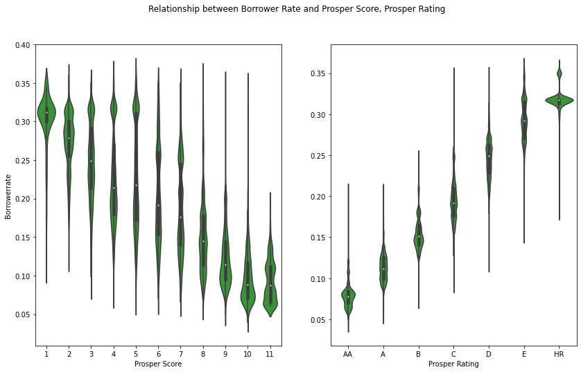

## Relationship Between Loan Amount And Income Group, Employment Status

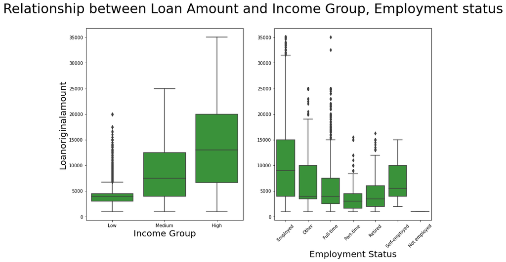

## Relationship Between Loan Amount And Home Owner Status

Borrowers who are home owners have access to higher amounts of loans, that those who do not own homes

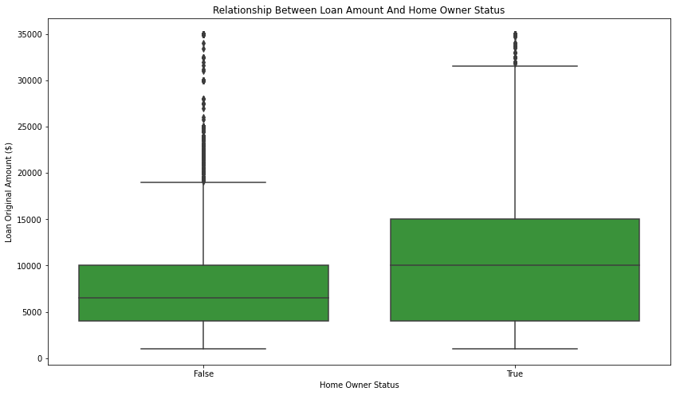

## Borrower Rate and Average Credit Score by Loan Payment Status

For people who are delinquent (defaulted,past due, charged-off payments), banks applies more restricted credit conditions (higher interest rates). Also these people have lower credit scores than people with good status.

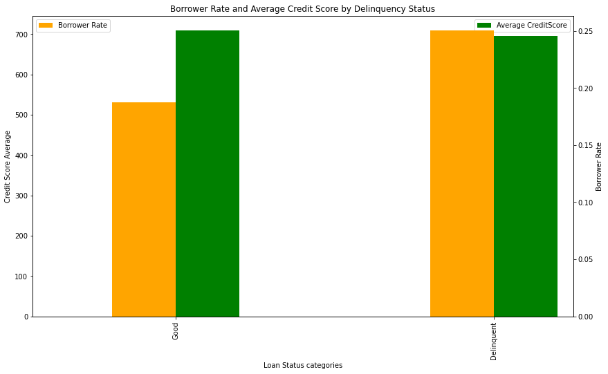

## Borrower Rate by Prosper Rating and Loan Terms

The lower the loan term, the lower the interest rate on the loan. As observed earlier, the better the Prosper Rating, the lower the interest rate on the loans. It should also be noted that HR, the least Prosper Rating has only 3 years loan terms.

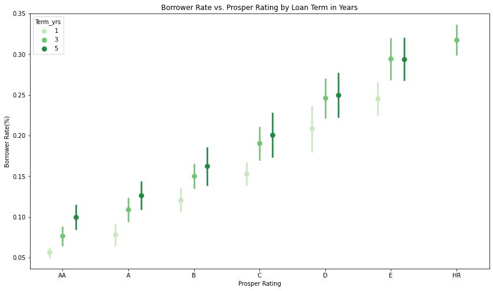

## Loan Amount by Home Owner Status and Income Group

As shown in the previous slides, having a collateral and a higher wage help getting higher loan amount. It is clearly visible that being a home owner is a very important element to get a higher loan amount.

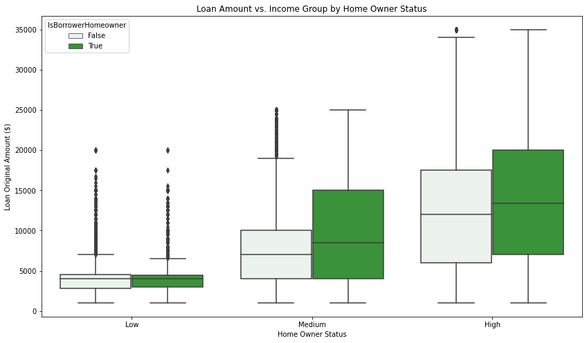

# Thank You For Your Attention